# Class Project - Machine Learning

Dr. B

Friday, December 12, 2014

```r
##Clear the environment
rm(list=ls())

##Turn off scientific notations for numbers becuase I hate it
options(scipen = 999)

##Set locale
Sys.setlocale("LC_ALL", "English")
```

```
## [1] "LC_COLLATE=English_United States.1252;LC_CTYPE=English_United States.1252;LC_MONETARY=English_United States.1252;LC_NUMERIC=C;LC_TIME=English_United States.1252"
```

```r
##Load libraries
call <- function(x)
{
        if (!require(x,character.only = TRUE))
        {
                install.packages(x,dep=TRUE)
        }
}

call("caret")
call("randomForest")
call("knitr")

##Set seed for reproducibility
set.seed(2345)

##Set location of Data Directory
datadir=('C:/Users/bryan_000/Documents/GitHub/Data/')
```

## Introduction

Using devices such as Jawbone Up, Nike FuelBand, and Fitbit it is now possible to collect a large amount of data about personal activity relatively inexpensively. These type of devices are part of the quantified self movement - a group of enthusiasts who take measurements about themselves regularly to improve their health, to find patterns in their behavior, or because they are tech geeks. One thing that people regularly do is quantify how much of a particular activity they do, but they rarely quantify how well they do it.

In this project, your goal will be to use data from accelerometers on the belt, forearm, arm, and dumbell of six young health participants. The participants were asked to perform one set of 10 repetitions of the Unilateral Dumbbell Biceps Curl in five different fashions: exactly according to the specification (Class A) throwing the elbows to the front (Class B) lifting the dumbbell only halfway (Class C) lowering the dumbbell only halfway (Class D) throwing the hips to the front (Class E)

(More information is available from the website [here](http://groupware.les.inf.puc-rio.br/har). (see the section on the Weight Lifting Exercise Dataset)).

### Load the Data

The data for this project come from this [source](http://groupware.les.inf.puc-rio.br/har). The training data for this project were downloaded from [here](https://d396qusza40orc.cloudfront.net/predmachlearn/pml-training.csv). The test data were downloaded from [here](https://d396qusza40orc.cloudfront.net/predmachlearn/pml-testing.csv).

```r
#Set name of training and validating datafiles
train.data=paste(datadir,"pml-training.csv",sep = "")
validate.data=paste(datadir,"pml-testing.csv",sep = "")
train.url="http://d396qusza40orc.cloudfront.net/predmachlearn/pml-training.csv"
validate.url="http://d396qusza40orc.cloudfront.net/predmachlearn/pml-testing.csv"

##Check for training file, download if not there
if (!file.exists(train.data)) {
  download.file(train.url, destfile = train.data)
}

##Check for testing file, download if not there
if (!file.exists(validate.data)) {
  download.file(validate.url, destfile = validate.data)
}

##Read the data
validate <- read.csv(validate.data, sep = ",", na.strings = c("", "NA"))
train <- read.csv(train.data, sep = ",", na.strings = c("", "NA"))

##Clean out variables not used
rm(validate.data)
rm(train.data)
rm(validate.url)
rm(train.url)
```

### Clean the Data

The training dataset contains 19622 observations with 160 variables. The validation dataset contains 20 observations with 160 variables. The variable that will be predicted is classe. Classe is as follows 5580, 3797, 3422, 3216, 3607

Once the data were loaded, the next step was to clean it. There are 100 columns with almost all missing values. Columns full of NAs were removed as were variables that were not in the test set. Because the test dataset had no time-dependence, these values were disregarded from the training dataset. In order to look only at the variables related to movement, the first seven variables were removed.

```r
##Clean the column names
names(validate) <- tolower(names(validate))
names(validate) <- gsub("_","",names(validate))
names(train) <- tolower(names(train))
names(train) <- gsub("_","",names(train))

##Remove columns full of NAs. Only use variables in test dataset.
vars <- names(validate[,colSums(is.na(validate)) == 0])[8:59]
train.df <- train[,c(vars,"classe")]
validate.df <- validate[,c(vars,"problemid")]

##clean out unused datasets
rm(validate)
rm(train)
```

After cleaning, the training dataset contained 19622 observations with 53 variables. The validation dataset contained 20 observations with 53 variables.

### Data Partition

Next, the training dataset was split to withhold 20% of the dataset for testing after the final model is constructed.

```r
##Split the training dataset
inTrain <- createDataPartition(train.df$classe, p = 0.80, list = FALSE)
training <- train.df[inTrain,]
testing <- train.df[-inTrain,]
validate <- validate.df

##clean out unused datasets
rm(inTrain)
rm(train.df)
rm(validate.df)
```

### Variables

Some predictor variables may be highly correlated. The find correlations function was used to identify correlations (positive or negative) greater than .90.

```r
outcome = which(names(training) == "classe")
highcorrcols = findCorrelation(abs(cor(training[,-outcome])),0.90)
highcorrvars = names(training)[highcorrcols]
training = training[,-highcorrcols]
outcome = which(names(training) == "classe")
```

The variables with high correlation were accelbeltz, rollbelt, accelbelty, accelbeltx, and gyrosarmy. These variables were then removed from the dataset, leaving 48 variables.

## Data Mining

### Random Forest

A random forest was used to discover the most important variables. The random forest method reduces overfitting and is good for nonlinear variables.

```r
fsRF = randomForest(training[,-outcome], training[,outcome], importance = T)
rfImp = data.frame(fsRF$importance)
impFeatures = order(-rfImp$MeanDecreaseGini)
inImp = createDataPartition(training$classe, p = 0.05, list = F)
```

The feature plot for the 4 most important variables:

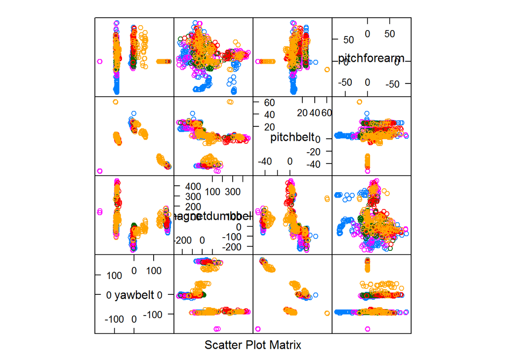

```r
featurePlot(training[inImp,impFeatures[1:4]],training$classe[inImp], plot = "pairs")
```

## Training

Training was accomplished using the k-nearest neighbors, decision tree, and random forest for comparison.

```r
##Set the training control
ctrl <- trainControl(method = "cv", number = 5, allowParallel = TRUE)

##k-nearest neighbors
modelknn <- train(classe ~ ., training, method = "knn", trControl = ctrl)
resultsknn <- data.frame(modelknn$results)

##Decision Tree
modeldt<- train(classe~., training, method="ctree", trControl = ctrl)
resultsdt <- data.frame(modeldt$results)

##Random Forest
modelrf <- train(classe ~ ., training, method = "rf", ntree = 200, trControl = ctrl)
resultsrf <- data.frame(modelrf$results)
```

### Confusion Matrix

confusion matrices between the k-nearest neighbors, decision tree, and random forest models were used to see how much they agree on the test set.

```r
##Fit the models to the test dataset
fitknn = predict(modelknn, testing)
fitrf = predict(modelrf, testing)
fitdt <-predict(modeldt, testing)

##Compare fits
confusionMatrix(fitrf, fitknn)
```

```
## Confusion Matrix and Statistics
##
##           Reference
## Prediction    A    B    C    D    E
##          A 1076   14    9   17    4
##          B   32  654   32   21   13
##          C    3   20  644   15    9
##          D    8    7   36  576   14
##          E    9   22   18   21  649
##
## Overall Statistics
##
##                Accuracy : 0.9174
##                  95% CI : (0.9084, 0.9258)
##     No Information Rate : 0.2875
##     P-Value [Acc > NIR] : < 0.00000000000000022
##
##                   Kappa : 0.8955
##  Mcnemar's Test P-Value : 0.00001478
##
## Statistics by Class:
##
##                      Class: A Class: B Class: C Class: D Class: E
## Sensitivity            0.9539   0.9121   0.8714   0.8862   0.9419
## Specificity            0.9843   0.9694   0.9852   0.9801   0.9784
## Pos Pred Value         0.9607   0.8697   0.9320   0.8986   0.9026
## Neg Pred Value         0.9814   0.9801   0.9706   0.9775   0.9875
## Prevalence             0.2875   0.1828   0.1884   0.1657   0.1756
## Detection Rate         0.2743   0.1667   0.1642   0.1468   0.1654
## Detection Prevalence   0.2855   0.1917   0.1761   0.1634   0.1833
## Balanced Accuracy      0.9691   0.9408   0.9283   0.9331   0.9601
```

```r
confusionMatrix(fitrf, fitdt)
```

```
## Confusion Matrix and Statistics
##
##           Reference
## Prediction    A    B    C    D    E
##          A 1074   23    3   12    8
##          B   45  641   33   14   19
##          C    5   43  602   20   21
##          D   14   13   23  571   20
##          E   14   16   19   18  652
##
## Overall Statistics
##
##                Accuracy : 0.9024
##                  95% CI : (0.8927, 0.9115)
##     No Information Rate : 0.2937
##     P-Value [Acc > NIR] : <0.0000000000000002
##
##                   Kappa : 0.8764
##  Mcnemar's Test P-Value : 0.3248
##
## Statistics by Class:
##
##                      Class: A Class: B Class: C Class: D Class: E
## Sensitivity            0.9323   0.8709   0.8853   0.8992   0.9056
## Specificity            0.9834   0.9652   0.9726   0.9787   0.9791
## Pos Pred Value         0.9589   0.8524   0.8712   0.8908   0.9068
## Neg Pred Value         0.9722   0.9700   0.9759   0.9805   0.9788
## Prevalence             0.2937   0.1876   0.1733   0.1619   0.1835
## Detection Rate         0.2738   0.1634   0.1535   0.1456   0.1662
## Detection Prevalence   0.2855   0.1917   0.1761   0.1634   0.1833
## Balanced Accuracy      0.9578   0.9180   0.9289   0.9390   0.9423
```

```r
confusionMatrix(fitknn, fitdt)
```

```
## Confusion Matrix and Statistics
##
##           Reference
## Prediction    A    B    C    D    E
##          A 1054   35   11   15   13
##          B   39  585   38   21   34
##          C   12   69  577   47   34
##          D   32   30   29  526   33
##          E   15   17   25   26  606
##
## Overall Statistics
##
##                Accuracy : 0.8534
##                  95% CI : (0.842, 0.8644)
##     No Information Rate : 0.2937
##     P-Value [Acc > NIR] : < 0.00000000000000022
##
##                   Kappa : 0.8144
##  Mcnemar's Test P-Value : 0.001133
##
## Statistics by Class:
##
##                      Class: A Class: B Class: C Class: D Class: E
## Sensitivity            0.9149   0.7948   0.8485   0.8283   0.8417
## Specificity            0.9733   0.9586   0.9500   0.9623   0.9741
## Pos Pred Value         0.9344   0.8159   0.7808   0.8092   0.8795
## Neg Pred Value         0.9649   0.9529   0.9677   0.9667   0.9647
## Prevalence             0.2937   0.1876   0.1733   0.1619   0.1835
## Detection Rate         0.2687   0.1491   0.1471   0.1341   0.1545
## Detection Prevalence   0.2875   0.1828   0.1884   0.1657   0.1756
## Balanced Accuracy      0.9441   0.8767   0.8993   0.8953   0.9079
```

```r
##Compare knn to test dataset
confusionMatrix(fitknn, testing$classe)
```

```
## Confusion Matrix and Statistics
##
##           Reference
## Prediction    A    B    C    D    E
##          A 1075   33    3    8    9
##          B    9  658   19    9   22
##          C    9   35  639   38   18
##          D   19   20   15  576   20
##          E    4   13    8   12  652
##
## Overall Statistics
##
##                Accuracy : 0.9177
##                  95% CI : (0.9086, 0.9261)
##     No Information Rate : 0.2845
##     P-Value [Acc > NIR] : < 0.00000000000000022
##
##                   Kappa : 0.8959
##  Mcnemar's Test P-Value : 0.000000248
##
## Statistics by Class:
##
##                      Class: A Class: B Class: C Class: D Class: E
## Sensitivity            0.9633   0.8669   0.9342   0.8958   0.9043
## Specificity            0.9811   0.9814   0.9691   0.9774   0.9884
## Pos Pred Value         0.9530   0.9177   0.8647   0.8862   0.9463
## Neg Pred Value         0.9853   0.9685   0.9859   0.9795   0.9787
## Prevalence             0.2845   0.1935   0.1744   0.1639   0.1838
## Detection Rate         0.2740   0.1677   0.1629   0.1468   0.1662
## Detection Prevalence   0.2875   0.1828   0.1884   0.1657   0.1756
## Balanced Accuracy      0.9722   0.9241   0.9517   0.9366   0.9464
```

```r
##Compare rf to test dataset
confusionMatrix(fitrf, testing$classe)
```

```
## Confusion Matrix and Statistics
##
##           Reference
## Prediction    A    B    C    D    E
##          A 1112    8    0    0    0
##          B    3  747    2    0    0
##          C    0    4  682    5    0
##          D    0    0    0  638    3
##          E    1    0    0    0  718
##
## Overall Statistics
##
##                Accuracy : 0.9934
##                  95% CI : (0.9903, 0.9957)
##     No Information Rate : 0.2845
##     P-Value [Acc > NIR] : < 0.00000000000000022
##
##                   Kappa : 0.9916
##  Mcnemar's Test P-Value : NA
##
## Statistics by Class:
##
##                      Class: A Class: B Class: C Class: D Class: E
## Sensitivity            0.9964   0.9842   0.9971   0.9922   0.9958
## Specificity            0.9971   0.9984   0.9972   0.9991   0.9997
## Pos Pred Value         0.9929   0.9934   0.9870   0.9953   0.9986
## Neg Pred Value         0.9986   0.9962   0.9994   0.9985   0.9991
## Prevalence             0.2845   0.1935   0.1744   0.1639   0.1838
## Detection Rate         0.2835   0.1904   0.1738   0.1626   0.1830
## Detection Prevalence   0.2855   0.1917   0.1761   0.1634   0.1833
## Balanced Accuracy      0.9968   0.9913   0.9971   0.9957   0.9978
```

```r
##Compare dt to test dataset
confusionMatrix(fitdt, testing$classe)
```

```
## Confusion Matrix and Statistics
##
##           Reference
## Prediction    A    B    C    D    E
##          A 1073   46    4   15   14
##          B   19  644   44   13   16
##          C    3   35  597   26   19
##          D   12   14   20  569   20
##          E    9   20   19   20  652
##
## Overall Statistics
##
##                Accuracy : 0.9011
##                  95% CI : (0.8913, 0.9103)
##     No Information Rate : 0.2845
##     P-Value [Acc > NIR] : <0.0000000000000002
##
##                   Kappa : 0.8748
##  Mcnemar's Test P-Value : 0.1296
##
## Statistics by Class:
##
##                      Class: A Class: B Class: C Class: D Class: E
## Sensitivity            0.9615   0.8485   0.8728   0.8849   0.9043
## Specificity            0.9719   0.9709   0.9744   0.9799   0.9788
## Pos Pred Value         0.9314   0.8750   0.8779   0.8961   0.9056
## Neg Pred Value         0.9845   0.9639   0.9732   0.9775   0.9785
## Prevalence             0.2845   0.1935   0.1744   0.1639   0.1838
## Detection Rate         0.2735   0.1642   0.1522   0.1450   0.1662
## Detection Prevalence   0.2937   0.1876   0.1733   0.1619   0.1835
## Balanced Accuracy      0.9667   0.9097   0.9236   0.9324   0.9415
```

### Accuracy

```r
accuracy.table <- data.frame(Model=c("Random Forest", "Decision Tree", "KNN"),
                        Accuracy=c(round(max(head(resultsrf)$Accuracy), 2),
                                   round(max(head(resultsdt)$Accuracy), 2),
                                   round(max(head(resultsknn)$Accuracy), 2)))
kable(accuracy.table)
```

| Model | Accuracy |
| --- | --- |
| Random Forest | 0.99 |
| Decision Tree | 0.88 |
| KNN | 0.90 |

## Predictions

Predictions were made using the k-nearest neighbors, decision tree, and random forest models.

```r
##Do the predictions
pred.1 <- predict(modelknn, validate)
pred.2 <- predict(modeldt, validate)
pred.3 <- predict(modelrf, validate)

##Make a table and check if they all agree
pred.df <- data.frame(rf.pred = pred.3, dt.pred = pred.2, knn.pred = pred.1)
colnames(pred.df) <- c("RF", "DT", "KNN")
kable(pred.df)
```

| RF | DT | KNN |
| --- | --- | --- |
| B | B | B |
| A | A | A |
| B | A | B |
| A | A | A |
| A | A | A |
| E | E | E |
| D | D | D |
| B | B | B |
| A | A | A |
| A | A | A |
| B | C | B |
| C | C | C |
| B | B | D |
| A | A | A |
| E | E | E |
| E | E | E |
| A | A | A |
| B | B | B |
| B | B | B |
| B | B | B |

## Submission

The random forest model was used to predict the 20 cases submitted to Coursera.

```r
answers <- pred.df$RF
  pml_write_files = function(x){
    n = length(x)
    for(i in 1:n){
      filename = paste0(datadir,"problem_id_",i,".txt")
      write.table(x[i],file=filename,quote=FALSE,row.names=FALSE,col.names=FALSE)
    }
  }
pml_write_files(answers)

ans = data.frame(problem.id = 1:20,answers = answers)
x <- as.matrix(format(ans))
rownames(x) <- rep("", nrow(x))
print(x, quote=FALSE, right=TRUE)
```

```
##  problem.id answers
##           1       B
##           2       A
##           3       B
##           4       A
##           5       A
##           6       E
##           7       D
##           8       B
##           9       A
##          10       A
##          11       B
##          12       C
##          13       B
##          14       A
##          15       E
##          16       E
##          17       A
##          18       B
##          19       B
##          20       B
```

All predictions were recorded as correct.